# Risk Factor Analysis

## Outcome Variable

**Outcome Variable:** ever_co

## Predictor Variables

**Intervention Variable:** mhtcm

**Adjustment Set:**

- arm
- W_mage
- meducyrs
- feducyrs
- delta_W_mage
- delta_meducyrs
- delta_feducyrs

## Stratifying Variables

The analysis was stratified on these variable(s):

- agecat
- studyid
- country

## Data Summary

| agecat | studyid | country | mhtcm | ever_co | n_cell | n |
| --- | --- | --- | --- | --- | --- | --- |
| 0-24 months | ki0047075b-MAL-ED | BANGLADESH | >=155 cm | 0 | 23 | 254 |
| 0-24 months | ki0047075b-MAL-ED | BANGLADESH | >=155 cm | 1 | 2 | 254 |
| 0-24 months | ki0047075b-MAL-ED | BANGLADESH | <151 cm | 0 | 131 | 254 |
| 0-24 months | ki0047075b-MAL-ED | BANGLADESH | <151 cm | 1 | 32 | 254 |
| 0-24 months | ki0047075b-MAL-ED | BANGLADESH | [151-155) cm | 0 | 61 | 254 |
| 0-24 months | ki0047075b-MAL-ED | BANGLADESH | [151-155) cm | 1 | 5 | 254 |
| 0-24 months | ki0047075b-MAL-ED | BRAZIL | >=155 cm | 0 | 128 | 222 |
| 0-24 months | ki0047075b-MAL-ED | BRAZIL | >=155 cm | 1 | 2 | 222 |
| 0-24 months | ki0047075b-MAL-ED | BRAZIL | <151 cm | 0 | 52 | 222 |
| 0-24 months | ki0047075b-MAL-ED | BRAZIL | <151 cm | 1 | 1 | 222 |
| 0-24 months | ki0047075b-MAL-ED | BRAZIL | [151-155) cm | 0 | 39 | 222 |
| 0-24 months | ki0047075b-MAL-ED | BRAZIL | [151-155) cm | 1 | 0 | 222 |
| 0-24 months | ki0047075b-MAL-ED | INDIA | >=155 cm | 0 | 49 | 242 |
| 0-24 months | ki0047075b-MAL-ED | INDIA | >=155 cm | 1 | 6 | 242 |
| 0-24 months | ki0047075b-MAL-ED | INDIA | <151 cm | 0 | 82 | 242 |
| 0-24 months | ki0047075b-MAL-ED | INDIA | <151 cm | 1 | 33 | 242 |
| 0-24 months | ki0047075b-MAL-ED | INDIA | [151-155) cm | 0 | 58 | 242 |
| 0-24 months | ki0047075b-MAL-ED | INDIA | [151-155) cm | 1 | 14 | 242 |
| 0-24 months | ki0047075b-MAL-ED | NEPAL | >=155 cm | 0 | 40 | 238 |
| 0-24 months | ki0047075b-MAL-ED | NEPAL | >=155 cm | 1 | 1 | 238 |
| 0-24 months | ki0047075b-MAL-ED | NEPAL | <151 cm | 0 | 114 | 238 |
| 0-24 months | ki0047075b-MAL-ED | NEPAL | <151 cm | 1 | 19 | 238 |
| 0-24 months | ki0047075b-MAL-ED | NEPAL | [151-155) cm | 0 | 62 | 238 |
| 0-24 months | ki0047075b-MAL-ED | NEPAL | [151-155) cm | 1 | 2 | 238 |
| 0-24 months | ki0047075b-MAL-ED | PERU | >=155 cm | 0 | 60 | 290 |
| 0-24 months | ki0047075b-MAL-ED | PERU | >=155 cm | 1 | 0 | 290 |
| 0-24 months | ki0047075b-MAL-ED | PERU | <151 cm | 0 | 161 | 290 |
| 0-24 months | ki0047075b-MAL-ED | PERU | <151 cm | 1 | 8 | 290 |
| 0-24 months | ki0047075b-MAL-ED | PERU | [151-155) cm | 0 | 57 | 290 |
| 0-24 months | ki0047075b-MAL-ED | PERU | [151-155) cm | 1 | 4 | 290 |

[output cut: 378 more lines]

The following strata were considered:

- agecat: 0-24 months, studyid: ki0047075b-MAL-ED, country: BANGLADESH
- agecat: 0-24 months, studyid: ki0047075b-MAL-ED, country: BRAZIL
- agecat: 0-24 months, studyid: ki0047075b-MAL-ED, country: INDIA
- agecat: 0-24 months, studyid: ki0047075b-MAL-ED, country: NEPAL
- agecat: 0-24 months, studyid: ki0047075b-MAL-ED, country: PERU
- agecat: 0-24 months, studyid: ki0047075b-MAL-ED, country: SOUTH AFRICA
- agecat: 0-24 months, studyid: ki0047075b-MAL-ED, country: TANZANIA, UNITED REPUBLIC OF
- agecat: 0-24 months, studyid: ki1000304b-SAS-CompFeed, country: INDIA
- agecat: 0-24 months, studyid: ki1000304b-SAS-FoodSuppl, country: INDIA
- agecat: 0-24 months, studyid: ki1017093-NIH-Birth, country: BANGLADESH
- agecat: 0-24 months, studyid: ki1017093b-PROVIDE, country: BANGLADESH
- agecat: 0-24 months, studyid: ki1017093c-NIH-Crypto, country: BANGLADESH
- agecat: 0-24 months, studyid: ki1066203-TanzaniaChild2, country: TANZANIA, UNITED REPUBLIC OF
- agecat: 0-24 months, studyid: ki1101329-Keneba, country: GAMBIA
- agecat: 0-24 months, studyid: ki1112895-Guatemala BSC, country: GUATEMALA
- agecat: 0-24 months, studyid: ki1112895-iLiNS-Zinc, country: BURKINA FASO
- agecat: 0-24 months, studyid: ki1119695-PROBIT, country: BELARUS
- agecat: 0-24 months, studyid: ki1126311-ZVITAMBO, country: ZIMBABWE
- agecat: 0-24 months, studyid: ki1135781-COHORTS, country: GUATEMALA
- agecat: 0-24 months, studyid: ki1135781-COHORTS, country: INDIA
- agecat: 0-24 months, studyid: ki1135781-COHORTS, country: PHILIPPINES
- agecat: 0-24 months, studyid: ki1148112-LCNI-5, country: MALAWI
- agecat: 0-24 months, studyid: kiGH5241-JiVitA-3, country: BANGLADESH
- agecat: 0-6 months, studyid: ki0047075b-MAL-ED, country: BANGLADESH
- agecat: 0-6 months, studyid: ki0047075b-MAL-ED, country: BRAZIL
- agecat: 0-6 months, studyid: ki0047075b-MAL-ED, country: INDIA
- agecat: 0-6 months, studyid: ki0047075b-MAL-ED, country: NEPAL
- agecat: 0-6 months, studyid: ki0047075b-MAL-ED, country: PERU
- agecat: 0-6 months, studyid: ki0047075b-MAL-ED, country: SOUTH AFRICA
- agecat: 0-6 months, studyid: ki0047075b-MAL-ED, country: TANZANIA, UNITED REPUBLIC OF
- agecat: 0-6 months, studyid: ki1000304b-SAS-CompFeed, country: INDIA
- agecat: 0-6 months, studyid: ki1000304b-SAS-FoodSuppl, country: INDIA
- agecat: 0-6 months, studyid: ki1017093-NIH-Birth, country: BANGLADESH
- agecat: 0-6 months, studyid: ki1017093b-PROVIDE, country: BANGLADESH
- agecat: 0-6 months, studyid: ki1017093c-NIH-Crypto, country: BANGLADESH
- agecat: 0-6 months, studyid: ki1066203-TanzaniaChild2, country: TANZANIA, UNITED REPUBLIC OF
- agecat: 0-6 months, studyid: ki1101329-Keneba, country: GAMBIA
- agecat: 0-6 months, studyid: ki1112895-Guatemala BSC, country: GUATEMALA
- agecat: 0-6 months, studyid: ki1119695-PROBIT, country: BELARUS
- agecat: 0-6 months, studyid: ki1126311-ZVITAMBO, country: ZIMBABWE
- agecat: 0-6 months, studyid: ki1135781-COHORTS, country: GUATEMALA
- agecat: 0-6 months, studyid: ki1135781-COHORTS, country: INDIA
- agecat: 0-6 months, studyid: ki1135781-COHORTS, country: PHILIPPINES
- agecat: 0-6 months, studyid: ki1148112-LCNI-5, country: MALAWI
- agecat: 0-6 months, studyid: kiGH5241-JiVitA-3, country: BANGLADESH
- agecat: 6-24 months, studyid: ki0047075b-MAL-ED, country: BANGLADESH
- agecat: 6-24 months, studyid: ki0047075b-MAL-ED, country: BRAZIL
- agecat: 6-24 months, studyid: ki0047075b-MAL-ED, country: INDIA
- agecat: 6-24 months, studyid: ki0047075b-MAL-ED, country: NEPAL
- agecat: 6-24 months, studyid: ki0047075b-MAL-ED, country: PERU
- agecat: 6-24 months, studyid: ki0047075b-MAL-ED, country: SOUTH AFRICA
- agecat: 6-24 months, studyid: ki0047075b-MAL-ED, country: TANZANIA, UNITED REPUBLIC OF
- agecat: 6-24 months, studyid: ki1000304b-SAS-CompFeed, country: INDIA
- agecat: 6-24 months, studyid: ki1000304b-SAS-FoodSuppl, country: INDIA
- agecat: 6-24 months, studyid: ki1017093-NIH-Birth, country: BANGLADESH
- agecat: 6-24 months, studyid: ki1017093b-PROVIDE, country: BANGLADESH
- agecat: 6-24 months, studyid: ki1017093c-NIH-Crypto, country: BANGLADESH
- agecat: 6-24 months, studyid: ki1066203-TanzaniaChild2, country: TANZANIA, UNITED REPUBLIC OF
- agecat: 6-24 months, studyid: ki1101329-Keneba, country: GAMBIA
- agecat: 6-24 months, studyid: ki1112895-Guatemala BSC, country: GUATEMALA
- agecat: 6-24 months, studyid: ki1112895-iLiNS-Zinc, country: BURKINA FASO
- agecat: 6-24 months, studyid: ki1119695-PROBIT, country: BELARUS
- agecat: 6-24 months, studyid: ki1126311-ZVITAMBO, country: ZIMBABWE
- agecat: 6-24 months, studyid: ki1135781-COHORTS, country: GUATEMALA
- agecat: 6-24 months, studyid: ki1135781-COHORTS, country: INDIA
- agecat: 6-24 months, studyid: ki1135781-COHORTS, country: PHILIPPINES
- agecat: 6-24 months, studyid: ki1148112-LCNI-5, country: MALAWI
- agecat: 6-24 months, studyid: kiGH5241-JiVitA-3, country: BANGLADESH

### Dropped Strata

Some strata were dropped due to rare outcomes:

- agecat: 0-24 months, studyid: ki0047075b-MAL-ED, country: BANGLADESH
- agecat: 0-24 months, studyid: ki0047075b-MAL-ED, country: BRAZIL
- agecat: 0-24 months, studyid: ki0047075b-MAL-ED, country: NEPAL
- agecat: 0-24 months, studyid: ki0047075b-MAL-ED, country: PERU
- agecat: 0-24 months, studyid: ki0047075b-MAL-ED, country: SOUTH AFRICA
- agecat: 0-24 months, studyid: ki1112895-Guatemala BSC, country: GUATEMALA
- agecat: 0-24 months, studyid: ki1119695-PROBIT, country: BELARUS
- agecat: 0-6 months, studyid: ki0047075b-MAL-ED, country: BANGLADESH
- agecat: 0-6 months, studyid: ki0047075b-MAL-ED, country: BRAZIL
- agecat: 0-6 months, studyid: ki0047075b-MAL-ED, country: INDIA
- agecat: 0-6 months, studyid: ki0047075b-MAL-ED, country: NEPAL
- agecat: 0-6 months, studyid: ki0047075b-MAL-ED, country: PERU
- agecat: 0-6 months, studyid: ki0047075b-MAL-ED, country: SOUTH AFRICA
- agecat: 0-6 months, studyid: ki0047075b-MAL-ED, country: TANZANIA, UNITED REPUBLIC OF
- agecat: 0-6 months, studyid: ki1000304b-SAS-FoodSuppl, country: INDIA
- agecat: 0-6 months, studyid: ki1017093c-NIH-Crypto, country: BANGLADESH
- agecat: 0-6 months, studyid: ki1066203-TanzaniaChild2, country: TANZANIA, UNITED REPUBLIC OF
- agecat: 0-6 months, studyid: ki1112895-Guatemala BSC, country: GUATEMALA
- agecat: 0-6 months, studyid: ki1119695-PROBIT, country: BELARUS
- agecat: 0-6 months, studyid: ki1135781-COHORTS, country: GUATEMALA
- agecat: 0-6 months, studyid: ki1148112-LCNI-5, country: MALAWI
- agecat: 6-24 months, studyid: ki0047075b-MAL-ED, country: BANGLADESH
- agecat: 6-24 months, studyid: ki0047075b-MAL-ED, country: BRAZIL
- agecat: 6-24 months, studyid: ki0047075b-MAL-ED, country: NEPAL
- agecat: 6-24 months, studyid: ki0047075b-MAL-ED, country: PERU
- agecat: 6-24 months, studyid: ki0047075b-MAL-ED, country: SOUTH AFRICA
- agecat: 6-24 months, studyid: ki1112895-Guatemala BSC, country: GUATEMALA
- agecat: 6-24 months, studyid: ki1119695-PROBIT, country: BELARUS

## Methods Detail

We’re interested in the causal parameters $E[Y_a]$ for all values of $a \in \mathcal{A}$. These parameters represent the mean outcome if, possibly contrary to fact, we intervened to set all units to have $A=a$. Under the randomization and positivity assumptions, these are identified by the statistical parameters $\psi_a=E_W[E_{Y|A,W}(Y|A=a,W)]$. In addition, we’re interested in the mean of $Y$, $E[Y]$ under no intervention (the observed mean). We will estimate these parameters by using SuperLearner to fit the relevant likelihood factors – $E_{Y|A,W}(Y|A=a,W)$ and $p(A=a|W)$, and then updating our likelihood fit using a joint TMLE.

For unadjusted analyses ($W=\{\}$), initial likelihoods were estimated using Lrnr_glm to estimate the simple $E(Y|A)$ and Lrnr_mean to estimate $p(A)$. For adjusted analyses, a small library containing Lrnr_glmnet, Lrnr_xgboost, and Lrnr_mean was used.

Having estimated these parameters, we will then use the delta method to estimate relative risks and attributable risks relative to a prespecified baseline level of $A$.

# Results Detail

## Results Plots

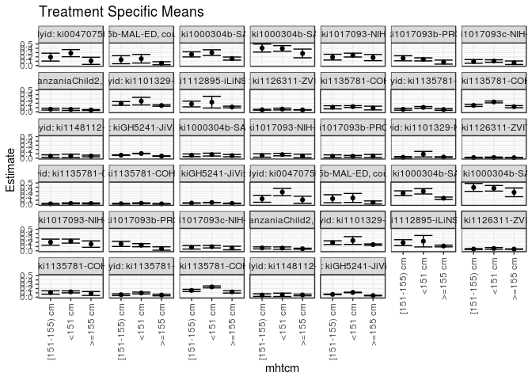

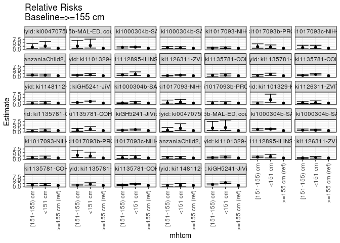

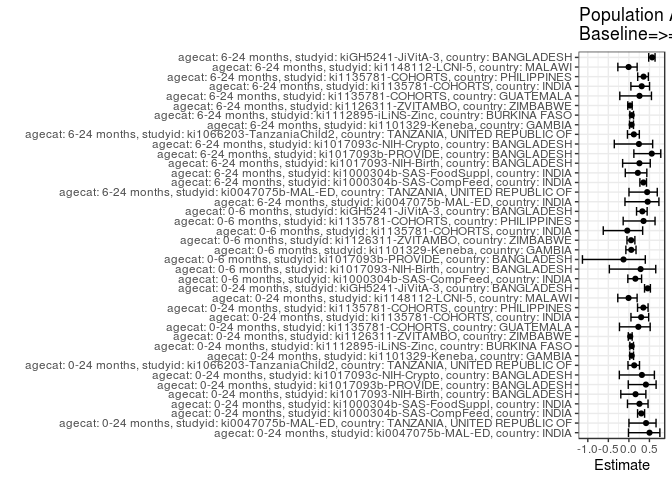

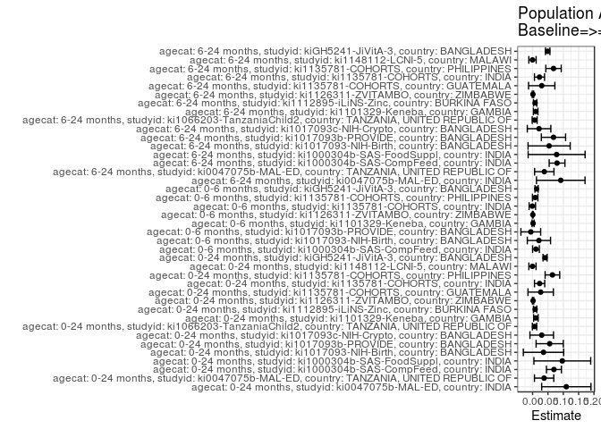

## Results Table

### Parameter: TSM

| agecat | studyid | country | intervention_level | baseline_level | estimate | ci_lower | ci_upper |
| --- | --- | --- | --- | --- | --- | --- | --- |
| 0-24 months | ki0047075b-MAL-ED | INDIA | >=155 cm | NA | 0.1090909 | 0.0265295 | 0.1916523 |
| 0-24 months | ki0047075b-MAL-ED | INDIA | <151 cm | NA | 0.2869565 | 0.2041119 | 0.3698012 |
| 0-24 months | ki0047075b-MAL-ED | INDIA | [151-155) cm | NA | 0.1944444 | 0.1028379 | 0.2860510 |
| 0-24 months | ki0047075b-MAL-ED | TANZANIA, UNITED REPUBLIC OF | >=155 cm | NA | 0.0522876 | 0.0169457 | 0.0876295 |
| 0-24 months | ki0047075b-MAL-ED | TANZANIA, UNITED REPUBLIC OF | <151 cm | NA | 0.1568627 | 0.0568577 | 0.2568678 |
| 0-24 months | ki0047075b-MAL-ED | TANZANIA, UNITED REPUBLIC OF | [151-155) cm | NA | 0.1346154 | 0.0416656 | 0.2275651 |
| 0-24 months | ki1000304b-SAS-CompFeed | INDIA | >=155 cm | NA | 0.1606722 | 0.1248126 | 0.1965318 |
| 0-24 months | ki1000304b-SAS-CompFeed | INDIA | <151 cm | NA | 0.2993897 | 0.2338113 | 0.3649682 |
| 0-24 months | ki1000304b-SAS-CompFeed | INDIA | [151-155) cm | NA | 0.2584398 | 0.1992115 | 0.3176682 |
| 0-24 months | ki1000304b-SAS-FoodSuppl | INDIA | >=155 cm | NA | 0.2797488 | 0.1787632 | 0.3807344 |
| 0-24 months | ki1000304b-SAS-FoodSuppl | INDIA | <151 cm | NA | 0.3964205 | 0.3315487 | 0.4612922 |
| 0-24 months | ki1000304b-SAS-FoodSuppl | INDIA | [151-155) cm | NA | 0.4052555 | 0.3125663 | 0.4979447 |
| 0-24 months | ki1017093-NIH-Birth | BANGLADESH | >=155 cm | NA | 0.1839955 | 0.1126887 | 0.2553023 |
| 0-24 months | ki1017093-NIH-Birth | BANGLADESH | <151 cm | NA | 0.2416222 | 0.1971856 | 0.2860587 |
| 0-24 months | ki1017093-NIH-Birth | BANGLADESH | [151-155) cm | NA | 0.1939291 | 0.1274502 | 0.2604079 |
| 0-24 months | ki1017093b-PROVIDE | BANGLADESH | >=155 cm | NA | 0.0787891 | 0.0323652 | 0.1252131 |
| 0-24 months | ki1017093b-PROVIDE | BANGLADESH | <151 cm | NA | 0.1419639 | 0.1063987 | 0.1775291 |
| 0-24 months | ki1017093b-PROVIDE | BANGLADESH | [151-155) cm | NA | 0.1674386 | 0.1084161 | 0.2264611 |
| 0-24 months | ki1017093c-NIH-Crypto | BANGLADESH | >=155 cm | NA | 0.0642857 | 0.0236320 | 0.1049395 |
| 0-24 months | ki1017093c-NIH-Crypto | BANGLADESH | <151 cm | NA | 0.1034483 | 0.0748104 | 0.1320861 |
| 0-24 months | ki1017093c-NIH-Crypto | BANGLADESH | [151-155) cm | NA | 0.0944444 | 0.0516935 | 0.1371954 |
| 0-24 months | ki1066203-TanzaniaChild2 | TANZANIA, UNITED REPUBLIC OF | >=155 cm | NA | 0.0428105 | 0.0325087 | 0.0531124 |
| 0-24 months | ki1066203-TanzaniaChild2 | TANZANIA, UNITED REPUBLIC OF | <151 cm | NA | 0.0568296 | 0.0328860 | 0.0807733 |
| 0-24 months | ki1066203-TanzaniaChild2 | TANZANIA, UNITED REPUBLIC OF | [151-155) cm | NA | 0.0620034 | 0.0410011 | 0.0830058 |
| 0-24 months | ki1101329-Keneba | GAMBIA | >=155 cm | NA | 0.1464997 | 0.1310879 | 0.1619116 |
| 0-24 months | ki1101329-Keneba | GAMBIA | <151 cm | NA | 0.2479169 | 0.1589211 | 0.3369127 |
| 0-24 months | ki1101329-Keneba | GAMBIA | [151-155) cm | NA | 0.1949488 | 0.1517868 | 0.2381108 |
| 0-24 months | ki1112895-iLiNS-Zinc | BURKINA FASO | >=155 cm | NA | 0.1117677 | 0.0918904 | 0.1316449 |
| 0-24 months | ki1112895-iLiNS-Zinc | BURKINA FASO | <151 cm | NA | 0.2244583 | 0.0889941 | 0.3599226 |
| 0-24 months | ki1112895-iLiNS-Zinc | BURKINA FASO | [151-155) cm | NA | 0.1816459 | 0.1152194 | 0.2480723 |

[output cut: 90 more lines]

### Parameter: E(Y)

| agecat | studyid | country | intervention_level | baseline_level | estimate | ci_lower | ci_upper |
| --- | --- | --- | --- | --- | --- | --- | --- |
| 0-24 months | ki0047075b-MAL-ED | INDIA | NA | NA | 0.2190083 | 0.1667935 | 0.2712230 |
| 0-24 months | ki0047075b-MAL-ED | TANZANIA, UNITED REPUBLIC OF | NA | NA | 0.0898438 | 0.0547459 | 0.1249416 |
| 0-24 months | ki1000304b-SAS-CompFeed | INDIA | NA | NA | 0.2302158 | 0.1856981 | 0.2747335 |
| 0-24 months | ki1000304b-SAS-FoodSuppl | INDIA | NA | NA | 0.3765281 | 0.3295143 | 0.4235419 |
| 0-24 months | ki1017093-NIH-Birth | BANGLADESH | NA | NA | 0.2195513 | 0.1870467 | 0.2520558 |
| 0-24 months | ki1017093b-PROVIDE | BANGLADESH | NA | NA | 0.1345291 | 0.1086533 | 0.1604050 |
| 0-24 months | ki1017093c-NIH-Crypto | BANGLADESH | NA | NA | 0.0940397 | 0.0732057 | 0.1148737 |
| 0-24 months | ki1066203-TanzaniaChild2 | TANZANIA, UNITED REPUBLIC OF | NA | NA | 0.0491734 | 0.0404458 | 0.0579009 |
| 0-24 months | ki1101329-Keneba | GAMBIA | NA | NA | 0.1572664 | 0.1427858 | 0.1717470 |
| 0-24 months | ki1112895-iLiNS-Zinc | BURKINA FASO | NA | NA | 0.1200249 | 0.0999720 | 0.1400777 |
| 0-24 months | ki1126311-ZVITAMBO | ZIMBABWE | NA | NA | 0.0469068 | 0.0427263 | 0.0510872 |
| 0-24 months | ki1135781-COHORTS | GUATEMALA | NA | NA | 0.1145098 | 0.0970244 | 0.1319952 |
| 0-24 months | ki1135781-COHORTS | INDIA | NA | NA | 0.0766404 | 0.0646915 | 0.0885893 |
| 0-24 months | ki1135781-COHORTS | PHILIPPINES | NA | NA | 0.1839080 | 0.1701456 | 0.1976705 |
| 0-24 months | ki1148112-LCNI-5 | MALAWI | NA | NA | 0.0501792 | 0.0353804 | 0.0649781 |
| 0-24 months | kiGH5241-JiVitA-3 | BANGLADESH | NA | NA | 0.0889419 | 0.0850166 | 0.0928673 |
| 0-6 months | ki1000304b-SAS-CompFeed | INDIA | NA | NA | 0.0694645 | 0.0441638 | 0.0947653 |
| 0-6 months | ki1017093-NIH-Birth | BANGLADESH | NA | NA | 0.0723473 | 0.0519719 | 0.0927227 |
| 0-6 months | ki1017093b-PROVIDE | BANGLADESH | NA | NA | 0.0448430 | 0.0291486 | 0.0605375 |
| 0-6 months | ki1101329-Keneba | GAMBIA | NA | NA | 0.0278293 | 0.0208847 | 0.0347739 |
| 0-6 months | ki1126311-ZVITAMBO | ZIMBABWE | NA | NA | 0.0123621 | 0.0101730 | 0.0145512 |
| 0-6 months | ki1135781-COHORTS | INDIA | NA | NA | 0.0225443 | 0.0158017 | 0.0292868 |
| 0-6 months | ki1135781-COHORTS | PHILIPPINES | NA | NA | 0.0236531 | 0.0182537 | 0.0290525 |
| 0-6 months | kiGH5241-JiVitA-3 | BANGLADESH | NA | NA | 0.0396299 | 0.0371163 | 0.0421435 |
| 6-24 months | ki0047075b-MAL-ED | INDIA | NA | NA | 0.2008547 | 0.1494120 | 0.2522974 |
| 6-24 months | ki0047075b-MAL-ED | TANZANIA, UNITED REPUBLIC OF | NA | NA | 0.0857143 | 0.0505889 | 0.1208396 |
| 6-24 months | ki1000304b-SAS-CompFeed | INDIA | NA | NA | 0.2255286 | 0.1871466 | 0.2639106 |
| 6-24 months | ki1000304b-SAS-FoodSuppl | INDIA | NA | NA | 0.3600000 | 0.3129020 | 0.4070980 |
| 6-24 months | ki1017093-NIH-Birth | BANGLADESH | NA | NA | 0.2103321 | 0.1759902 | 0.2446740 |
| 6-24 months | ki1017093b-PROVIDE | BANGLADESH | NA | NA | 0.1223491 | 0.0963874 | 0.1483108 |
| 6-24 months | ki1017093c-NIH-Crypto | BANGLADESH | NA | NA | 0.0863014 | 0.0659171 | 0.1066856 |
| 6-24 months | ki1066203-TanzaniaChild2 | TANZANIA, UNITED REPUBLIC OF | NA | NA | 0.0554435 | 0.0453713 | 0.0655158 |
| 6-24 months | ki1101329-Keneba | GAMBIA | NA | NA | 0.1544750 | 0.1397785 | 0.1691716 |
| 6-24 months | ki1112895-iLiNS-Zinc | BURKINA FASO | NA | NA | 0.1200249 | 0.0999720 | 0.1400777 |
| 6-24 months | ki1126311-ZVITAMBO | ZIMBABWE | NA | NA | 0.0416377 | 0.0374209 | 0.0458544 |
| 6-24 months | ki1135781-COHORTS | GUATEMALA | NA | NA | 0.1152513 | 0.0968196 | 0.1336830 |
| 6-24 months | ki1135781-COHORTS | INDIA | NA | NA | 0.0721649 | 0.0603481 | 0.0839818 |
| 6-24 months | ki1135781-COHORTS | PHILIPPINES | NA | NA | 0.1908832 | 0.1763448 | 0.2054216 |
| 6-24 months | ki1148112-LCNI-5 | MALAWI | NA | NA | 0.0510328 | 0.0359888 | 0.0660768 |
| 6-24 months | kiGH5241-JiVitA-3 | BANGLADESH | NA | NA | 0.0868884 | 0.0822172 | 0.0915596 |

### Parameter: RR

| agecat | studyid | country | intervention_level | baseline_level | estimate | ci_lower | ci_upper |
| --- | --- | --- | --- | --- | --- | --- | --- |
| 0-24 months | ki0047075b-MAL-ED | INDIA | >=155 cm | >=155 cm | 1.0000000 | 1.0000000 | 1.000000 |
| 0-24 months | ki0047075b-MAL-ED | INDIA | <151 cm | >=155 cm | 2.6304348 | 1.1701604 | 5.913025 |
| 0-24 months | ki0047075b-MAL-ED | INDIA | [151-155) cm | >=155 cm | 1.7824074 | 0.7308807 | 4.346778 |
| 0-24 months | ki0047075b-MAL-ED | TANZANIA, UNITED REPUBLIC OF | >=155 cm | >=155 cm | 1.0000000 | 1.0000000 | 1.000000 |
| 0-24 months | ki0047075b-MAL-ED | TANZANIA, UNITED REPUBLIC OF | <151 cm | >=155 cm | 3.0000000 | 1.1846760 | 7.597014 |
| 0-24 months | ki0047075b-MAL-ED | TANZANIA, UNITED REPUBLIC OF | [151-155) cm | >=155 cm | 2.5745192 | 0.9796292 | 6.765978 |
| 0-24 months | ki1000304b-SAS-CompFeed | INDIA | >=155 cm | >=155 cm | 1.0000000 | 1.0000000 | 1.000000 |
| 0-24 months | ki1000304b-SAS-CompFeed | INDIA | <151 cm | >=155 cm | 1.8633573 | 1.5279110 | 2.272449 |
| 0-24 months | ki1000304b-SAS-CompFeed | INDIA | [151-155) cm | >=155 cm | 1.6084913 | 1.2428648 | 2.081678 |
| 0-24 months | ki1000304b-SAS-FoodSuppl | INDIA | >=155 cm | >=155 cm | 1.0000000 | 1.0000000 | 1.000000 |
| 0-24 months | ki1000304b-SAS-FoodSuppl | INDIA | <151 cm | >=155 cm | 1.4170586 | 0.9533305 | 2.106358 |
| 0-24 months | ki1000304b-SAS-FoodSuppl | INDIA | [151-155) cm | >=155 cm | 1.4486407 | 0.9447982 | 2.221173 |
| 0-24 months | ki1017093-NIH-Birth | BANGLADESH | >=155 cm | >=155 cm | 1.0000000 | 1.0000000 | 1.000000 |
| 0-24 months | ki1017093-NIH-Birth | BANGLADESH | <151 cm | >=155 cm | 1.3131959 | 0.8548292 | 2.017343 |
| 0-24 months | ki1017093-NIH-Birth | BANGLADESH | [151-155) cm | >=155 cm | 1.0539879 | 0.6277939 | 1.769515 |
| 0-24 months | ki1017093b-PROVIDE | BANGLADESH | >=155 cm | >=155 cm | 1.0000000 | 1.0000000 | 1.000000 |
| 0-24 months | ki1017093b-PROVIDE | BANGLADESH | <151 cm | >=155 cm | 1.8018205 | 0.9495920 | 3.418897 |
| 0-24 months | ki1017093b-PROVIDE | BANGLADESH | [151-155) cm | >=155 cm | 2.1251481 | 1.0691965 | 4.223971 |
| 0-24 months | ki1017093c-NIH-Crypto | BANGLADESH | >=155 cm | >=155 cm | 1.0000000 | 1.0000000 | 1.000000 |
| 0-24 months | ki1017093c-NIH-Crypto | BANGLADESH | <151 cm | >=155 cm | 1.6091954 | 0.8068674 | 3.209337 |
| 0-24 months | ki1017093c-NIH-Crypto | BANGLADESH | [151-155) cm | >=155 cm | 1.4691358 | 0.6750113 | 3.197517 |
| 0-24 months | ki1066203-TanzaniaChild2 | TANZANIA, UNITED REPUBLIC OF | >=155 cm | >=155 cm | 1.0000000 | 1.0000000 | 1.000000 |
| 0-24 months | ki1066203-TanzaniaChild2 | TANZANIA, UNITED REPUBLIC OF | <151 cm | >=155 cm | 1.3274682 | 0.8171548 | 2.156472 |
| 0-24 months | ki1066203-TanzaniaChild2 | TANZANIA, UNITED REPUBLIC OF | [151-155) cm | >=155 cm | 1.4483217 | 0.9560457 | 2.194075 |
| 0-24 months | ki1101329-Keneba | GAMBIA | >=155 cm | >=155 cm | 1.0000000 | 1.0000000 | 1.000000 |
| 0-24 months | ki1101329-Keneba | GAMBIA | <151 cm | >=155 cm | 1.6922686 | 1.1643217 | 2.459606 |
| 0-24 months | ki1101329-Keneba | GAMBIA | [151-155) cm | >=155 cm | 1.3307109 | 1.0419239 | 1.699540 |
| 0-24 months | ki1112895-iLiNS-Zinc | BURKINA FASO | >=155 cm | >=155 cm | 1.0000000 | 1.0000000 | 1.000000 |
| 0-24 months | ki1112895-iLiNS-Zinc | BURKINA FASO | <151 cm | >=155 cm | 2.0082584 | 1.0707529 | 3.766604 |
| 0-24 months | ki1112895-iLiNS-Zinc | BURKINA FASO | [151-155) cm | >=155 cm | 1.6252094 | 1.1368494 | 2.323356 |

[output cut: 90 more lines]

### Parameter: PAR

| agecat | studyid | country | intervention_level | baseline_level | estimate | ci_lower | ci_upper |
| --- | --- | --- | --- | --- | --- | --- | --- |
| 0-24 months | ki0047075b-MAL-ED | INDIA | >=155 cm | NA | 0.1099174 | 0.0296403 | 0.1901944 |
| 0-24 months | ki0047075b-MAL-ED | TANZANIA, UNITED REPUBLIC OF | >=155 cm | NA | 0.0375562 | 0.0061253 | 0.0689871 |
| 0-24 months | ki1000304b-SAS-CompFeed | INDIA | >=155 cm | NA | 0.0695436 | 0.0451841 | 0.0939032 |
| 0-24 months | ki1000304b-SAS-FoodSuppl | INDIA | >=155 cm | NA | 0.0967793 | 0.0042353 | 0.1893234 |
| 0-24 months | ki1017093-NIH-Birth | BANGLADESH | >=155 cm | NA | 0.0355558 | -0.0301468 | 0.1012583 |
| 0-24 months | ki1017093b-PROVIDE | BANGLADESH | >=155 cm | NA | 0.0557400 | 0.0114233 | 0.1000567 |
| 0-24 months | ki1017093c-NIH-Crypto | BANGLADESH | >=155 cm | NA | 0.0297540 | -0.0086368 | 0.0681448 |
| 0-24 months | ki1066203-TanzaniaChild2 | TANZANIA, UNITED REPUBLIC OF | >=155 cm | NA | 0.0063628 | -0.0005848 | 0.0133105 |
| 0-24 months | ki1101329-Keneba | GAMBIA | >=155 cm | NA | 0.0107666 | 0.0034664 | 0.0180669 |
| 0-24 months | ki1112895-iLiNS-Zinc | BURKINA FASO | >=155 cm | NA | 0.0082572 | 0.0028987 | 0.0136157 |
| 0-24 months | ki1126311-ZVITAMBO | ZIMBABWE | >=155 cm | NA | 0.0015731 | -0.0006369 | 0.0037832 |
| 0-24 months | ki1135781-COHORTS | GUATEMALA | >=155 cm | NA | 0.0263507 | -0.0150511 | 0.0677524 |
| 0-24 months | ki1135781-COHORTS | INDIA | >=155 cm | NA | 0.0228601 | 0.0062051 | 0.0395151 |
| 0-24 months | ki1135781-COHORTS | PHILIPPINES | >=155 cm | NA | 0.0646098 | 0.0408311 | 0.0883885 |
| 0-24 months | ki1148112-LCNI-5 | MALAWI | >=155 cm | NA | -0.0004044 | -0.0121093 | 0.0113004 |
| 0-24 months | kiGH5241-JiVitA-3 | BANGLADESH | >=155 cm | NA | 0.0406333 | 0.0339694 | 0.0472971 |
| 0-6 months | ki1000304b-SAS-CompFeed | INDIA | >=155 cm | NA | 0.0109787 | -0.0000303 | 0.0219876 |
| 0-6 months | ki1017093-NIH-Birth | BANGLADESH | >=155 cm | NA | 0.0206231 | -0.0172615 | 0.0585078 |
| 0-6 months | ki1017093b-PROVIDE | BANGLADESH | >=155 cm | NA | -0.0058816 | -0.0380513 | 0.0262881 |
| 0-6 months | ki1101329-Keneba | GAMBIA | >=155 cm | NA | 0.0016163 | -0.0018388 | 0.0050713 |
| 0-6 months | ki1126311-ZVITAMBO | ZIMBABWE | >=155 cm | NA | 0.0006729 | -0.0005206 | 0.0018664 |
| 0-6 months | ki1135781-COHORTS | INDIA | >=155 cm | NA | -0.0008791 | -0.0113429 | 0.0095847 |
| 0-6 months | ki1135781-COHORTS | PHILIPPINES | >=155 cm | NA | 0.0084347 | -0.0004672 | 0.0173366 |
| 0-6 months | kiGH5241-JiVitA-3 | BANGLADESH | >=155 cm | NA | 0.0129850 | 0.0078570 | 0.0181130 |
| 6-24 months | ki0047075b-MAL-ED | INDIA | >=155 cm | NA | 0.0917638 | 0.0126502 | 0.1708774 |
| 6-24 months | ki0047075b-MAL-ED | TANZANIA, UNITED REPUBLIC OF | >=155 cm | NA | 0.0380952 | 0.0065391 | 0.0696514 |
| 6-24 months | ki1000304b-SAS-CompFeed | INDIA | >=155 cm | NA | 0.0797286 | 0.0540713 | 0.1053860 |
| 6-24 months | ki1000304b-SAS-FoodSuppl | INDIA | >=155 cm | NA | 0.0782576 | -0.0145297 | 0.1710448 |
| 6-24 months | ki1017093-NIH-Birth | BANGLADESH | >=155 cm | NA | 0.0538763 | -0.0147920 | 0.1225447 |
| 6-24 months | ki1017093b-PROVIDE | BANGLADESH | >=155 cm | NA | 0.0680855 | 0.0285827 | 0.1075884 |
| 6-24 months | ki1017093c-NIH-Crypto | BANGLADESH | >=155 cm | NA | 0.0210840 | -0.0172877 | 0.0594556 |
| 6-24 months | ki1066203-TanzaniaChild2 | TANZANIA, UNITED REPUBLIC OF | >=155 cm | NA | 0.0067402 | -0.0013050 | 0.0147854 |
| 6-24 months | ki1101329-Keneba | GAMBIA | >=155 cm | NA | 0.0100760 | 0.0026600 | 0.0174920 |
| 6-24 months | ki1112895-iLiNS-Zinc | BURKINA FASO | >=155 cm | NA | 0.0082955 | 0.0029375 | 0.0136534 |
| 6-24 months | ki1126311-ZVITAMBO | ZIMBABWE | >=155 cm | NA | 0.0011648 | -0.0010667 | 0.0033964 |
| 6-24 months | ki1135781-COHORTS | GUATEMALA | >=155 cm | NA | 0.0297301 | -0.0131157 | 0.0725759 |
| 6-24 months | ki1135781-COHORTS | INDIA | >=155 cm | NA | 0.0225271 | 0.0060448 | 0.0390094 |
| 6-24 months | ki1135781-COHORTS | PHILIPPINES | >=155 cm | NA | 0.0682309 | 0.0431621 | 0.0932998 |
| 6-24 months | ki1148112-LCNI-5 | MALAWI | >=155 cm | NA | -0.0003506 | -0.0122349 | 0.0115337 |
| 6-24 months | kiGH5241-JiVitA-3 | BANGLADESH | >=155 cm | NA | 0.0492038 | 0.0419586 | 0.0564491 |

### Parameter: PAF

| agecat | studyid | country | intervention_level | baseline_level | estimate | ci_lower | ci_upper |
| --- | --- | --- | --- | --- | --- | --- | --- |
| 0-24 months | ki0047075b-MAL-ED | INDIA | >=155 cm | NA | 0.5018868 | -0.0101766 | 0.7543828 |
| 0-24 months | ki0047075b-MAL-ED | TANZANIA, UNITED REPUBLIC OF | >=155 cm | NA | 0.4180165 | 0.0012619 | 0.6608672 |
| 0-24 months | ki1000304b-SAS-CompFeed | INDIA | >=155 cm | NA | 0.3020801 | 0.2114569 | 0.3822885 |
| 0-24 months | ki1000304b-SAS-FoodSuppl | INDIA | >=155 cm | NA | 0.2570308 | -0.0342417 | 0.4662725 |
| 0-24 months | ki1017093-NIH-Birth | BANGLADESH | >=155 cm | NA | 0.1619474 | -0.1967684 | 0.4131428 |
| 0-24 months | ki1017093b-PROVIDE | BANGLADESH | >=155 cm | NA | 0.4143340 | -0.0155353 | 0.6622425 |
| 0-24 months | ki1017093c-NIH-Crypto | BANGLADESH | >=155 cm | NA | 0.3163984 | -0.2327008 | 0.6209046 |
| 0-24 months | ki1066203-TanzaniaChild2 | TANZANIA, UNITED REPUBLIC OF | >=155 cm | NA | 0.1293959 | -0.0221109 | 0.2584448 |
| 0-24 months | ki1101329-Keneba | GAMBIA | >=155 cm | NA | 0.0684611 | 0.0212146 | 0.1134270 |
| 0-24 months | ki1112895-iLiNS-Zinc | BURKINA FASO | >=155 cm | NA | 0.0687959 | 0.0235181 | 0.1119742 |
| 0-24 months | ki1126311-ZVITAMBO | ZIMBABWE | >=155 cm | NA | 0.0335369 | -0.0146675 | 0.0794512 |
| 0-24 months | ki1135781-COHORTS | GUATEMALA | >=155 cm | NA | 0.2301171 | -0.2293997 | 0.5178787 |
| 0-24 months | ki1135781-COHORTS | INDIA | >=155 cm | NA | 0.2982773 | 0.0502327 | 0.4815417 |
| 0-24 months | ki1135781-COHORTS | PHILIPPINES | >=155 cm | NA | 0.3513158 | 0.2106063 | 0.4669438 |
| 0-24 months | ki1148112-LCNI-5 | MALAWI | >=155 cm | NA | -0.0080600 | -0.2705026 | 0.2001709 |
| 0-24 months | kiGH5241-JiVitA-3 | BANGLADESH | >=155 cm | NA | 0.4568518 | 0.3810192 | 0.5233939 |
| 0-6 months | ki1000304b-SAS-CompFeed | INDIA | >=155 cm | NA | 0.1580471 | -0.0256809 | 0.3088643 |
| 0-6 months | ki1017093-NIH-Birth | BANGLADESH | >=155 cm | NA | 0.2850575 | -0.4757933 | 0.6536488 |
| 0-6 months | ki1017093b-PROVIDE | BANGLADESH | >=155 cm | NA | -0.1311594 | -1.1303471 | 0.3993835 |
| 0-6 months | ki1101329-Keneba | GAMBIA | >=155 cm | NA | 0.0580777 | -0.0737124 | 0.1736916 |
| 0-6 months | ki1126311-ZVITAMBO | ZIMBABWE | >=155 cm | NA | 0.0544350 | -0.0466895 | 0.1457896 |
| 0-6 months | ki1135781-COHORTS | INDIA | >=155 cm | NA | -0.0389961 | -0.6239218 | 0.3352433 |
| 0-6 months | ki1135781-COHORTS | PHILIPPINES | >=155 cm | NA | 0.3566012 | -0.1391201 | 0.6365950 |
| 0-6 months | kiGH5241-JiVitA-3 | BANGLADESH | >=155 cm | NA | 0.3276562 | 0.1865957 | 0.4442540 |
| 6-24 months | ki0047075b-MAL-ED | INDIA | >=155 cm | NA | 0.4568665 | -0.0954428 | 0.7307080 |
| 6-24 months | ki0047075b-MAL-ED | TANZANIA, UNITED REPUBLIC OF | >=155 cm | NA | 0.4444444 | 0.0022396 | 0.6906652 |
| 6-24 months | ki1000304b-SAS-CompFeed | INDIA | >=155 cm | NA | 0.3535190 | 0.2678514 | 0.4291628 |
| 6-24 months | ki1000304b-SAS-FoodSuppl | INDIA | >=155 cm | NA | 0.2173821 | -0.0874178 | 0.4367475 |
| 6-24 months | ki1017093-NIH-Birth | BANGLADESH | >=155 cm | NA | 0.2561489 | -0.1524588 | 0.5198836 |
| 6-24 months | ki1017093b-PROVIDE | BANGLADESH | >=155 cm | NA | 0.5564858 | 0.1210607 | 0.7762020 |
| 6-24 months | ki1017093c-NIH-Crypto | BANGLADESH | >=155 cm | NA | 0.2443064 | -0.3552454 | 0.5786204 |
| 6-24 months | ki1066203-TanzaniaChild2 | TANZANIA, UNITED REPUBLIC OF | >=155 cm | NA | 0.1215686 | -0.0344321 | 0.2540432 |
| 6-24 months | ki1101329-Keneba | GAMBIA | >=155 cm | NA | 0.0652273 | 0.0163018 | 0.1117195 |
| 6-24 months | ki1112895-iLiNS-Zinc | BURKINA FASO | >=155 cm | NA | 0.0691146 | 0.0237630 | 0.1123594 |
| 6-24 months | ki1126311-ZVITAMBO | ZIMBABWE | >=155 cm | NA | 0.0279758 | -0.0270529 | 0.0800561 |
| 6-24 months | ki1135781-COHORTS | GUATEMALA | >=155 cm | NA | 0.2579587 | -0.2212192 | 0.5491184 |
| 6-24 months | ki1135781-COHORTS | INDIA | >=155 cm | NA | 0.3121608 | 0.0487177 | 0.5026474 |
| 6-24 months | ki1135781-COHORTS | PHILIPPINES | >=155 cm | NA | 0.3574486 | 0.2142275 | 0.4745651 |
| 6-24 months | ki1148112-LCNI-5 | MALAWI | >=155 cm | NA | -0.0068699 | -0.2688686 | 0.2010307 |
| 6-24 months | kiGH5241-JiVitA-3 | BANGLADESH | >=155 cm | NA | 0.5662879 | 0.4821760 | 0.6367373 |